# AdvML_MLOps_Tourism_Package_Prediction_Project

[figure not shown]

Artificial Intelligence and Machine Learning

Advance ML & MLOps - Project

[figure not shown]

Visit With Us : Wellness Tourism Package Customer Targeting

# Problem Statement

## Business Context

"Visit with Us," a leading travel company, is revolutionizing the tourism industry by leveraging data-driven strategies to optimize operations and customer engagement. While introducing a new package offering, such as the Wellness Tourism Package, the company faces challenges in targeting the right customers efficiently. The manual approach to identifying potential customers is inconsistent, time-consuming, and prone to errors, leading to missed opportunities and suboptimal campaign performance.

To address these issues, the company aims to implement a scalable and automated system that integrates customer data, predicts potential buyers, and enhances decision-making for marketing strategies. By utilizing an MLOps pipeline, the company seeks to achieve seamless integration of data preprocessing, model development, deployment, and CI/CD practices for continuous improvement. This system will ensure efficient targeting of customers, timely updates to the predictive model, and adaptation to evolving customer behaviors, ultimately driving growth and customer satisfaction.

## Objective

As an MLOps Engineer at "Visit with Us," your responsibility is to design and deploy an MLOps pipeline on GitHub to automate the end-to-end workflow for predicting customer purchases. The primary objective is to build a model that predicts whether a customer will purchase the newly introduced Wellness Tourism Package before contacting them.

The pipeline will include data cleaning, preprocessing, transformation, model building, training, evaluation, and deployment, ensuring consistent performance and scalability. By leveraging GitHub Actions for CI/CD integration, the system will enable automated updates, streamline model deployment, and improve operational efficiency. This robust predictive solution will empower policymakers to make data-driven decisions, enhance marketing strategies, and effectively target potential customers, thereby driving customer acquisition and business growth.

## Data Dictionary

The dataset contains customer and interaction data that serve as key attributes for predicting the likelihood of purchasing the Wellness Tourism Package. The detailed attributes are:

**Customer Details**

1. `CustomerID` : Unique identifier for each customer.
2. `ProdTaken` : Target variable indicating whether the customer has purchased a package (0: No, 1: Yes).
3. `Age` : Age of the customer.
4. `TypeofContact` : The method by which the customer was contacted (Company Invited or Self Inquiry).
5. `CityTier` : The city category based on development, population, and living standards (Tier 1 > Tier 2 > Tier 3).
6. `Occupation` : Customer's occupation (e.g., Salaried, Freelancer).
7. `Gender` : Gender of the customer (Male, Female).
8. `NumberOfPersonVisiting` : Total number of people accompanying the customer on the trip.
9. `PreferredPropertyStar` : Preferred hotel rating by the customer.
10. `MaritalStatus` : Marital status of the customer (Single, Married, Divorced).
11. `NumberOfTrips` : Average number of trips the customer takes annually.
12. `Passport` : Whether the customer holds a valid passport (0: No, 1: Yes).
13. `OwnCar` : Whether the customer owns a car (0: No, 1: Yes).
14. `NumberOfChildrenVisiting` : Number of children below age 5 accompanying the customer.
15. `Designation` : Customer's designation in their current organization.
16. `MonthlyIncome` : Gross monthly income of the customer.

**Customer Interaction Data**

1. `PitchSatisfactionScore` : Score indicating the customer's satisfaction with the sales pitch.
2. `ProductPitched` : The type of product pitched to the customer.
3. `NumberOfFollowups` : Total number of follow-ups by the salesperson after the sales pitch.-
4. `DurationOfPitch` : Duration of the sales pitch delivered to the customer.

# Data Analysis

**Note** :

- This is not a part of the Rubric, but is done for better understanding of the data
- Some of the observations here will be used in the `Data Preparation` stage further in the notebook

## Install and Import Libraries

**Please Note:**

- The notebook is run using a local host jupyter running on a uv environment *(to manage session timeout challenge of google colab)*.
- No packages are installed via the notebook. They are used from the uv env

```python
# import necessary libraries
import os
import pandas as pd
```

## Loading the dataset

```python
# Load the dataset from a CSV file into a Pandas DataFrame
visit_with_us_data = pd.read_csv("tourism.csv", low_memory=False)

# Create a copy of the dataframe
data = visit_with_us_data.copy()
```

## Data overview

### Data Shape

```python
# print the dataset shape
data.shape
```

```
(4128, 21)
```

- The dataset has 4128 rows and 21 columns

### Columns

```python
# Display the column names of the dataset
data.columns
```

```
Index(['Unnamed: 0', 'CustomerID', 'ProdTaken', 'Age', 'TypeofContact',
       'CityTier', 'DurationOfPitch', 'Occupation', 'Gender',
       'NumberOfPersonVisiting', 'NumberOfFollowups', 'ProductPitched',
       'PreferredPropertyStar', 'MaritalStatus', 'NumberOfTrips', 'Passport',
       'PitchSatisfactionScore', 'OwnCar', 'NumberOfChildrenVisiting',
       'Designation', 'MonthlyIncome'],
      dtype='object')
```

```python
# Display the column names of the dataset
data.columns.size
```

```
21
```

- The are 21 columns in the dataset and the first column is unnamed (index column)
- The unnamed column can be dropped as it is not required for analysis
- The other 20 columns match the given data dictionary

### Data Types

```python
# checking column datatypes and number of non-null values
print(data.info())
```

```
<class 'pandas.core.frame.DataFrame'>
RangeIndex: 4128 entries, 0 to 4127
Data columns (total 21 columns):
 #   Column                    Non-Null Count  Dtype
---  ------                    --------------  -----
 0   Unnamed: 0                4128 non-null   int64
 1   CustomerID                4128 non-null   int64
 2   ProdTaken                 4128 non-null   int64
 3   Age                       4128 non-null   float64
 4   TypeofContact             4128 non-null   object
 5   CityTier                  4128 non-null   int64
 6   DurationOfPitch           4128 non-null   float64
 7   Occupation                4128 non-null   object
 8   Gender                    4128 non-null   object
 9   NumberOfPersonVisiting    4128 non-null   int64
 10  NumberOfFollowups         4128 non-null   float64
 11  ProductPitched            4128 non-null   object
 12  PreferredPropertyStar     4128 non-null   float64
 13  MaritalStatus             4128 non-null   object
 14  NumberOfTrips             4128 non-null   float64
 15  Passport                  4128 non-null   int64
 16  PitchSatisfactionScore    4128 non-null   int64
 17  OwnCar                    4128 non-null   int64
 18  NumberOfChildrenVisiting  4128 non-null   float64
 19  Designation               4128 non-null   object
 20  MonthlyIncome             4128 non-null   float64
dtypes: float64(7), int64(8), object(6)
memory usage: 677.4+ KB
None
```

Note : The unnamed column is ignored as it is an index column.

**Numeric Features:**

There are 14 numeric features in the dataset:

1. CustomerID
2. ProdTaken
3. Age
4. CityTier
5. DurationOfPitch
6. NumberOfPersonVisiting
7. NumberOfFollowups
8. PreferredPropertyStar
9. NumberOfTrips
10. Passport
11. PitchSatisfactionScore
12. OwnCar
13. NumberOfChildrenVisiting
14. MonthlyIncome

**Categorical Features:**

1. TypeofContact
2. Occupation
3. Gender
4. ProductPitched
5. MaritalStatus
6. Designation

### First '5' rows and identifier Column

```python
# Display the first five rows of the dataset
data.head()
```

|  | Unnamed: 0 | CustomerID | ProdTaken | Age | TypeofContact | CityTier | DurationOfPitch | Occupation | Gender | NumberOfPersonVisiting | ... | ProductPitched | PreferredPropertyStar | MaritalStatus | NumberOfTrips | Passport | PitchSatisfactionScore | OwnCar | NumberOfChildrenVisiting | Designation | MonthlyIncome |
| --- | --- | --- | --- | --- | --- | --- | --- | --- | --- | --- | --- | --- | --- | --- | --- | --- | --- | --- | --- | --- | --- |
| 0 | 0 | 200000 | 1 | 41.0 | Self Enquiry | 3 | 6.0 | Salaried | Female | 3 | ... | Deluxe | 3.0 | Single | 1.0 | 1 | 2 | 1 | 0.0 | Manager | 20993.0 |
| 1 | 1 | 200001 | 0 | 49.0 | Company Invited | 1 | 14.0 | Salaried | Male | 3 | ... | Deluxe | 4.0 | Divorced | 2.0 | 0 | 3 | 1 | 2.0 | Manager | 20130.0 |
| 2 | 2 | 200002 | 1 | 37.0 | Self Enquiry | 1 | 8.0 | Free Lancer | Male | 3 | ... | Basic | 3.0 | Single | 7.0 | 1 | 3 | 0 | 0.0 | Executive | 17090.0 |
| 3 | 3 | 200003 | 0 | 33.0 | Company Invited | 1 | 9.0 | Salaried | Female | 2 | ... | Basic | 3.0 | Divorced | 2.0 | 1 | 5 | 1 | 1.0 | Executive | 17909.0 |
| 4 | 5 | 200005 | 0 | 32.0 | Company Invited | 1 | 8.0 | Salaried | Male | 3 | ... | Basic | 3.0 | Single | 1.0 | 0 | 5 | 1 | 1.0 | Executive | 18068.0 |

5 rows × 21 columns

## Data Validation

### Missing Values

```python
# checking for missing values
data.isnull().sum()
```

```
Unnamed: 0                  0
CustomerID                  0
ProdTaken                   0
Age                         0
TypeofContact               0
CityTier                    0
DurationOfPitch             0
Occupation                  0
Gender                      0
NumberOfPersonVisiting      0
NumberOfFollowups           0
ProductPitched              0
PreferredPropertyStar       0
MaritalStatus               0
NumberOfTrips               0
Passport                    0
PitchSatisfactionScore      0
OwnCar                      0
NumberOfChildrenVisiting    0
Designation                 0
MonthlyIncome               0
dtype: int64
```

- No missing values are observed in the dataset

### Duplicate Values

```python
# checking for duplicate values
data.duplicated().sum()
```

```
np.int64(0)
```

- No duplicate values are observed in the dataset
- During the pipeline process, we can safely drop the unnnamed and CustomerID columns

### Category columns validation

```python
# define the list of categorical features in a single variable
categorical_features = [
    "TypeofContact",
    "Occupation",
    "Gender",
    "ProductPitched",
    "MaritalStatus",
    "Designation"
]
```

```python
# print the unique values in each category feature
for category in categorical_features:
    print(f"Unique values in `{category}` are ")
    print(data[category].value_counts())
    print('-' * 50)
```

```
Unique values in `TypeofContact` are
TypeofContact
Self Enquiry       2918
Company Invited    1210
Name: count, dtype: int64
--------------------------------------------------
Unique values in `Occupation` are
Occupation
Salaried          1999
Small Business    1746
Large Business     381
Free Lancer          2
Name: count, dtype: int64
--------------------------------------------------
Unique values in `Gender` are
Gender
Male       2463
Female     1510
Fe Male     155
Name: count, dtype: int64
--------------------------------------------------
Unique values in `ProductPitched` are
ProductPitched
Basic           1615
Deluxe          1422
Standard         737
Super Deluxe     250
King             104
Name: count, dtype: int64
--------------------------------------------------
Unique values in `MaritalStatus` are
MaritalStatus
Married      1990
Divorced      789
Unmarried     682
Single        667
Name: count, dtype: int64
--------------------------------------------------
Unique values in `Designation` are
Designation
Executive         1615
Manager           1422
Senior Manager     737
AVP                250
VP                 104
Name: count, dtype: int64
--------------------------------------------------
```

**Observations:** Following are the unique values in each categorical column:

- `TypeofContact` : "Self Enquiry", "Company Invited"
- `Occupation` : "Salaried", "Small Business", "Large Business", "Free Lancer"
- `Gender` : " Male", "Female", "Fe Male"
  - **Note**: There is a spelling mistake in this column value as Female is spelled as "Fe Male" and it has 155 occurrences
- `ProductPitched` : "Basic", "Deluxe", "Standard", "Super Deluxe", "King"
- `MaritalStatus` : "Married", "Divorced", "Unmarried", "Single"
- `Designation` : "Executive", "Manager", "Senior Manager", "AVP", "VP"

### Numeric columns validation

```python
numeric_features = [
    "CustomerID",
    "ProdTaken",
    "Age",
    "CityTier",
    "DurationOfPitch",
    "NumberOfPersonVisiting",
    "NumberOfFollowups",
    "PreferredPropertyStar",
    "NumberOfTrips",
    "Passport",
    "PitchSatisfactionScore",
    "OwnCar",
    "NumberOfChildrenVisiting",
    "MonthlyIncome"
]

# Create a dictionary to store columns with negative values
negative_values = {}

# Loop through each numerical column to check for negatives
for col in numeric_features:
    # Filter rows where the column has negative values
    negatives = data[data[col] < 0][col]

    # If any negative values exist, store them in the dictionary
    if not negatives.empty:
        negative_values[col] = negatives

# Display the columns with negative values (if any)
negative_values
```

```
{}
```

**Observations:**

- No negative values are observed in any of the numeric columns

### Statistical Summary

```python
# display the statistical summary of all columns
data.describe(include='all').T
```

|  | count | unique | top | freq | mean | std | min | 25% | 50% | 75% | max |
| --- | --- | --- | --- | --- | --- | --- | --- | --- | --- | --- | --- |
| Unnamed: 0 | 4128.0 | NaN | NaN | NaN | 2527.763808 | 1409.439133 | 0.0 | 1320.75 | 2603.5 | 3748.25 | 4887.0 |
| CustomerID | 4128.0 | NaN | NaN | NaN | 202527.763808 | 1409.439133 | 200000.0 | 201320.75 | 202603.5 | 203748.25 | 204887.0 |
| ProdTaken | 4128.0 | NaN | NaN | NaN | 0.193072 | 0.394757 | 0.0 | 0.0 | 0.0 | 0.0 | 1.0 |
| Age | 4128.0 | NaN | NaN | NaN | 37.231831 | 9.174521 | 18.0 | 31.0 | 36.0 | 43.0 | 61.0 |
| TypeofContact | 4128 | 2 | Self Enquiry | 2918 | NaN | NaN | NaN | NaN | NaN | NaN | NaN |
| CityTier | 4128.0 | NaN | NaN | NaN | 1.663275 | 0.92064 | 1.0 | 1.0 | 1.0 | 3.0 | 3.0 |
| DurationOfPitch | 4128.0 | NaN | NaN | NaN | 15.584787 | 8.398142 | 5.0 | 9.0 | 14.0 | 20.0 | 127.0 |
| Occupation | 4128 | 4 | Salaried | 1999 | NaN | NaN | NaN | NaN | NaN | NaN | NaN |
| Gender | 4128 | 3 | Male | 2463 | NaN | NaN | NaN | NaN | NaN | NaN | NaN |
| NumberOfPersonVisiting | 4128.0 | NaN | NaN | NaN | 2.94937 | 0.718818 | 1.0 | 2.0 | 3.0 | 3.0 | 5.0 |
| NumberOfFollowups | 4128.0 | NaN | NaN | NaN | 3.741521 | 1.006786 | 1.0 | 3.0 | 4.0 | 4.0 | 6.0 |
| ProductPitched | 4128 | 5 | Basic | 1615 | NaN | NaN | NaN | NaN | NaN | NaN | NaN |
| PreferredPropertyStar | 4128.0 | NaN | NaN | NaN | 3.578488 | 0.795031 | 3.0 | 3.0 | 3.0 | 4.0 | 5.0 |
| MaritalStatus | 4128 | 4 | Married | 1990 | NaN | NaN | NaN | NaN | NaN | NaN | NaN |
| NumberOfTrips | 4128.0 | NaN | NaN | NaN | 3.2953 | 1.8563 | 1.0 | 2.0 | 3.0 | 4.0 | 22.0 |
| Passport | 4128.0 | NaN | NaN | NaN | 0.2953 | 0.456233 | 0.0 | 0.0 | 0.0 | 1.0 | 1.0 |
| PitchSatisfactionScore | 4128.0 | NaN | NaN | NaN | 3.060804 | 1.363064 | 1.0 | 2.0 | 3.0 | 4.0 | 5.0 |
| OwnCar | 4128.0 | NaN | NaN | NaN | 0.612161 | 0.487317 | 0.0 | 0.0 | 1.0 | 1.0 | 1.0 |
| NumberOfChildrenVisiting | 4128.0 | NaN | NaN | NaN | 1.223595 | 0.852685 | 0.0 | 1.0 | 1.0 | 2.0 | 3.0 |
| Designation | 4128 | 5 | Executive | 1615 | NaN | NaN | NaN | NaN | NaN | NaN | NaN |
| MonthlyIncome | 4128.0 | NaN | NaN | NaN | 23178.464147 | 4506.614622 | 1000.0 | 20751.0 | 22418.0 | 25301.0 | 98678.0 |

#### Observations

**Target Variable (`ProdTaken`)**

- Mean is 0.193, indicating that approximately 19.3% of customers purchased the package.
- This also implies that the dataset has class imbalance, with a significantly higher number of customers not purchasing the package compared to those who did.

**Customer Segmentation Insights:**

- Young, urban professionals dominate: Average age 37, mostly from Tier 1 cities (66%)
- Middle-income segment: Median income ~23K suggests targeting middle-class professionals
- Income disparity: Wide range (1K-98K) indicates diverse customer base requiring segmented strategies

**Sales Process Observations:**

- Self-inquiry customers dominate (71%) hinting organic interest is stronger than outbound
- Pitch satisfaction is moderate (3.06/5) and there appears still room for sales process improvement
- High variation in pitch duration (5-127 min, mean 15.6), sales approach are not consistent
- Multiple touchpoints needed: Sales cycles are long with an average of 3.7 for follow-ups

**Product & Customer Alignment:**

- Basic package is the most pitched
- Designation distribution mirrors pitch complexity i.e., More executives pitched basic packages
- Customers have high percentage of car ownership (61%) indicating mobility and disposable income

# Data Registration

## Data folder and CSV

1. Create the `tourism_project/data` directory to save the data for registration
2. Copy the `tourism.csv` file into the created directory

```python
# create directory to save the data
os.makedirs("tourism_project/data", exist_ok=True)
```

```python
# list the files in the created directory for verification
os.listdir("tourism_project/data")
```

```
['tourism.csv']
```

## Model Building and data_register.py

### Pre-work

Before the model building process following steps are done as pre-requisites:

1. Github repository is created to host the MLOps pipeline code at https://github.com/nsriram/tourism_project/
2. Hugging Face space is created to host the project https://huggingface.co/spaces/nsriram78/tourism-package-prediction
   - The space should be of Docker type with streamlit as the SDK
3. Hugging Face token is generated from the Hugging Face account settings page and added as a secret in the github repository settings page

### Model building folder creation

Create `tourism_project/model_building` folder for storing the model building files

```python
# Create a folder for storing the model building files
os.makedirs("tourism_project/model_building", exist_ok=True)
```

### Data Registration Script

`data_register.py` will be stored in the `tourism_project/model_building` directory.

The following steps are performed in the `data_register.py` script:

1. Import the huggingface hub libraries
2. Load the Hugging Face token from the environment variable (set as a secret in the github repository settings page)
3. Create a dataset repo (if it is not already created)
4. Upload the data folder to the created repo

```python
%%writefile tourism_project/model_building/data_register.py
# Import necessary libraries from huggingface_hub
from huggingface_hub.utils import RepositoryNotFoundError
from huggingface_hub import HfApi, create_repo
import os

# Define repository details
repo_id = "nsriram78/tourism-package-prediction"
repo_type = "dataset"

# Initialize API client using the Hugging Face token from environment variables
api = HfApi(token=os.getenv("HF_TOKEN"))

# Step 1: Check if the space exists
try:
    api.repo_info(repo_id=repo_id, repo_type=repo_type)
    print(f"Space '{repo_id}' already exists. Using it.")
except RepositoryNotFoundError:
    print(f"Space '{repo_id}' not found. Creating new space...")
    create_repo(repo_id=repo_id, repo_type=repo_type, private=False)
    print(f"Space '{repo_id}' created.")

# Step 2: Upload the data folder to the repo
api.upload_folder(
    folder_path="data",
    repo_id=repo_id,
    repo_type=repo_type,
)
```

```
Writing tourism_project/model_building/data_register.py
```

# Data Preparation

## Steps

1. Import necessary libraries
2. Load the dataset from the Hugging Face dataset repo
3. Drop the unnamed column and CustomerID column
4. Fix the Gender column spelling mistake
5. Define feature set and target variable
6. Split the dataset into train and test sets, stratified on the target variable
7. Save the prepared data to CSV files
8. Upload the prepared data files to the Hugging Face dataset repo

**Note:**

- Label encoding, one-hot encoding, scaling etc will be done in the model building stage.
- Doing it here would require saving the encoders and scalers which would complicate the pipeline

```python
%%writefile tourism_project/model_building/prep.py
# import necessary libraries
import pandas as pd
import os
from sklearn.model_selection import train_test_split
from huggingface_hub import HfApi

# Login to Hugging Face using the token from environment variable
api = HfApi(token=os.getenv("HF_TOKEN"))

# Load the dataset from Hugging Face dataset repo
DATASET_PATH = "hf://datasets/nsriram78/tourism-package-prediction/tourism.csv"

# Load the dataset
df = pd.read_csv(DATASET_PATH)
print("Dataset loaded successfully.")

# Drop the column that has no name
df = df.loc[:, ~df.columns.str.contains('^Unnamed')]

# Drop the CustomerID column as it is an identifier
df.drop(columns=['CustomerID'], inplace=True)

# Fix the Gender column and change Fe Male to Female
df['Gender'] = df['Gender'].replace('Fe Male', 'Female')

# define the categorical, numeric features and target variable
target_variable = "ProdTaken"

# Define feature set and target variable
X = df.drop('ProdTaken', axis=1)
y = df[target_variable]

# Split dataset into train and test, stratified on target variable as it is imbalanced
Xtrain, Xtest, ytrain, ytest = train_test_split(
    X, y, test_size=0.2, random_state=42, stratify=y
)

# Save the prepared data to CSV files
Xtrain.to_csv("Xtrain.csv", index=False)
Xtest.to_csv("Xtest.csv", index=False)
ytrain.to_csv("ytrain.csv", index=False)
ytest.to_csv("ytest.csv", index=False)

print(f"Training set: X={Xtrain.shape}, y={ytrain.shape}")
print(f"Test set: X={Xtest.shape}, y={ytest.shape}")

# List of created files
files = ["Xtrain.csv", "Xtest.csv", "ytrain.csv", "ytest.csv"]

# Upload the prepared data files to Hugging Face dataset repo
for file_path in files:
    api.upload_file(
        path_or_fileobj=file_path,
        path_in_repo=file_path.split("/")[-1],
        repo_id="nsriram78/tourism-package-prediction",
        repo_type="dataset",
    )

print("Data preparation complete! All 4 files uploaded.")
```

```
Overwriting tourism_project/model_building/prep.py
```

# Model Evaluation Criteria

## What does "Visit With Us" want?

Primary Business Objective:

- Identify customers who are likely to purchase the Wellness Tourism Package before contacting them
- Maximize conversion rates and revenue from the new package offering
- Optimize marketing efficiency by targeting the right customers

Business Constraints:

- Limited marketing budget and sales team bandwidth
- High competition in tourism industry
- Need to balance customer acquisition with operational costs

Key Success Factors:

1. Capture maximum potential buyers - Don't miss revenue opportunities
2. Minimize wasted marketing efforts - Don't spam non-interested customers
3. Maintain customer satisfaction - Only contact relevant prospects

## Which case is more important?

Scenario Analysis:

| Case | Description | Business Impact | Severity |
| --- | --- | --- | --- |
| True Positive (TP) | Correctly predict buyer, contact them, they purchase | ✅ Revenue gained | High Value |
| True Negative (TN) | Correctly predict non-buyer, don't contact | ✅ Effort saved | Low Cost |
| False Positive (FP) | Predict buyer, contact them, they don't purchase | ⚠️ Wasted effort + minor annoyance | Low-Medium Cost |
| False Negative (FN) | Predict non-buyer, don't contact, missed sale | ❌ Revenue lost | High Cost |

**Cost-Benefit Analysis:**

False Negative (Missing a Buyer) Costs:

- Lost revenue from package sale (high value)
- Lost potential for upselling and future bookings
- Missed customer lifetime value

False Positive (Contacting Non-Buyer) Costs:

- Marketing/sales effort wasted (phone call, email, follow-up)
- Minor customer annoyance (if done respectfully)

**Conclusion:** False Negatives (FN) are MORE COSTLY than False Positives (FP)

Therefore: **Recall** is MORE important than Precision

## Which metric to optimize?

Metric Selection Rationale:

| Metric | Why Not Use It? | Why Use It? |
| --- | --- | --- |
| Accuracy | ❌ Misleading for imbalanced data (81% by predicting all "no purchase") | - |
| Precision | ⚠️ Focuses only on marketing efficiency, may miss many buyers | For controlling marketing costs (secondary) |
| Recall | ⚠️ Alone may lead to too many false contacts | ✅ Captures maximum buyers (primary goal) |
| F1-Score | - | ✅ Balances both recall and precision (OPTIMAL) |

Primary Metric: F1-Score

Why F1-Score is OPTIMAL:

1. Handles Class Imbalance (19.3% buyers vs 80.7% non-buyers)
2. Balances Business Priorities of maximizing revenue and maintaining efficiency
3. Interpretable for Stakeholders, standard industry metric
4. Aligned with Business Goal

# Model Training

## Experiment approach

- Model will be built for both developer localhost and production environment
- On developer localhost, the model will be built and evaluated in the notebook itself and the csv files will be loaded from local disk
- In production environment, the model will be built in the `train.py` script and the csv files will be loaded from the Hugging Face dataset repo
- In both cases, the experiments will be tracked using MLFlow

## Experiment Tracking with MLFlow (Developer Localhost)

### Start MLFlow server on localhost

Note : not using colab and using local machine with uv

```python
# import necessary libraries
import subprocess

# Start MLflow UI on port 5000
process = subprocess.Popen([
    "mlflow", "server",
    "--host", "127.0.0.1",
    "--port", "5000",
    "--gunicorn-opts", "--log-level warning"
])
```

```python
# import MLFlow and set up tracking URI to localhost and experiment
import mlflow

mlflow.set_tracking_uri("http://127.0.0.1:5000")
mlflow.set_experiment("tourism-package-prediction-experiment")
```

```
2025/12/26 02:17:23 INFO mlflow.store.db.utils: Creating initial MLflow database tables...
2025/12/26 02:17:23 INFO mlflow.store.db.utils: Updating database tables
2025/12/26 02:17:23 INFO alembic.runtime.migration: Context impl SQLiteImpl.
2025/12/26 02:17:23 INFO alembic.runtime.migration: Will assume non-transactional DDL.
2025/12/26 02:17:23 INFO alembic.runtime.migration: Context impl SQLiteImpl.
2025/12/26 02:17:23 INFO alembic.runtime.migration: Will assume non-transactional DDL.
```

```
<Experiment: artifact_location='mlflow-artifacts:/1', creation_time=1766682573427, experiment_id='1', last_update_time=1766682573427, lifecycle_stage='active', name='tourism-package-prediction-experiment', tags={}>
```

### Dev Experiment Steps

**Note:**

- Dev experiment essentially involves doing the entire model building process on localhost. Unlike production there is no integration to Hugging Face
- Ngrok is also not used here as the MLFlow UI is accessed directly on localhost
1. Import necessary libraries
2. Load the dataset from local CSV file
3. Do the preprocessing as this is run on localhost
   - Drop the unnamed column and CustomerID column
   - Fix the Gender column
4. Define feature set and target variable
5. Split the dataset into train and test sets, stratified on the target variable
6. Define feature groups
7. Create preprocessing pipeline with OrdinalEncoder for categorical features and passthrough for numeric features as XGBoost can handle numeric inputs directly and standard scaling is not mandatory
8. Set the class weight to handle class imbalance
9. Define base XGBoost model
10. Define hyperparameter grid and the Model pipeline
11. Start MLFlow run
    - Hyperparameter tuning using GridSearchCV
    - Log all parameter combinations and their mean test scores
    - Log best parameters separately in main run
    - Store and evaluate the best model
    - Log the metrics for the best model
    - End MLFlow run
12. View the MLFlow UI at `http://localhost:5000`

```python
# suppress mlflow logger to improve jupyter notebook readability on dev experiment mode
import os
os.environ['MLFLOW_SUPPRESS_PRINTING_URL_TO_STDOUT'] = 'True'

# import necessary libraries
import pandas as pd
import xgboost as xgb
import logging
from sklearn.model_selection import train_test_split
from sklearn.compose import ColumnTransformer
from sklearn.preprocessing import OrdinalEncoder
from sklearn.pipeline import make_pipeline
from sklearn.model_selection import GridSearchCV
from sklearn.metrics import classification_report

# Load the dataset from local CSV file
df = pd.read_csv("tourism.csv", low_memory=False)
print("Dataset loaded successfully.")

# Drop the column that has no name
df = df.loc[:, ~df.columns.str.contains('^Unnamed')]

# Drop the CustomerID column as it is an identifier
df.drop(columns=['CustomerID'], inplace=True)

# Fix the Gender column and change Fe Male to Female
df['Gender'] = df['Gender'].replace('Fe Male', 'Female')

# define the categorical, numeric features and target variable
target_variable = "ProdTaken"

# Define feature set and target variable
X = df.drop('ProdTaken', axis=1)
y = df[target_variable]

# Split dataset into train and test, stratified on target variable as it is imbalanced
Xtrain, Xtest, ytrain, ytest = train_test_split(
    X, y, test_size=0.2, random_state=42, stratify=y
)

# Define feature groups
nominal_features = ['TypeofContact', 'Occupation', 'Gender', 'ProductPitched', 'MaritalStatus']
ordinal_features = ['Designation']
numeric_features = [
    'Age', 'CityTier', 'DurationOfPitch', 'NumberOfPersonVisiting',
    'NumberOfFollowups', 'PreferredPropertyStar', 'NumberOfTrips',
    'Passport', 'PitchSatisfactionScore', 'OwnCar',
    'NumberOfChildrenVisiting', 'MonthlyIncome'
]

# Create preprocessing pipeline with OrdinalEncoder for categorical features and passthrough for numeric features as XGBoost can handle numeric inputs directly and standard scaling is not mandatory
preprocessor = ColumnTransformer(
    transformers=[
        ('num', 'passthrough', numeric_features),  # Keep numeric as-is
        ('nom', OrdinalEncoder(handle_unknown='use_encoded_value', unknown_value=-1), nominal_features),
        ('ord', OrdinalEncoder(
            categories=[['Executive', 'Manager', 'Senior Manager', 'AVP', 'VP']],
            handle_unknown='use_encoded_value', unknown_value=-1
        ), ordinal_features)
    ]
)

# Set the clas weight to handle class imbalance
class_weight = ytrain.value_counts()[0] / ytrain.value_counts()[1]

# Define base XGBoost model
xgb_model = xgb.XGBClassifier(
    eval_metric='logloss', scale_pos_weight=class_weight, random_state=42
)

# Define hyperparameter grid
param_grid = {
    'xgbclassifier__n_estimators': [150, 175, 200, 225, 250],  # number of tree to build
    'xgbclassifier__max_depth': [3, 4, 5],  # maximum depth of each tree
    'xgbclassifier__colsample_bytree': [0.4, 0.5, 0.6],
    # percentage of attributes to be considered (randomly) for each tree
    'xgbclassifier__colsample_bylevel': [0.4, 0.5, 0.6],
    # percentage of attributes to be considered (randomly) for each level of a tree
    'xgbclassifier__learning_rate': [0.05, 0.1, 0.15],  # learning rate
    'xgbclassifier__reg_lambda': [0.5, 0.6, 0.7],  # L2 regularization factor
}

# Model pipeline
model_pipeline = make_pipeline(preprocessor, xgb_model)

# Suppress MLflow client INFO logs for dev experiment mode to improve jupyter notebook readability
logging.getLogger("mlflow").setLevel(logging.WARNING)


# Start MLFlow run
with mlflow.start_run():
    # Hyperparameter tuning
    grid_search = GridSearchCV(model_pipeline, param_grid, cv=5, scoring='f1', n_jobs=-1)
    grid_search.fit(Xtrain, ytrain)

    # Log all parameter combinations and their mean test scores
    results = grid_search.cv_results_
    for i in range(len(results['params'])):
        param_set = results['params'][i]
        mean_score = results['mean_test_score'][i]
        std_score = results['std_test_score'][i]

        # Log each combination as a separate MLflow run
        with mlflow.start_run(nested=True):
            mlflow.log_params(param_set)
            mlflow.log_metric("mean_test_score", mean_score)
            mlflow.log_metric("std_test_score", std_score)

    # Log the best parameters separately in main run
    mlflow.log_params(grid_search.best_params_)

    # Store and evaluate the best model
    best_model = grid_search.best_estimator_

    classification_threshold = 0.45

    # predict on training data using the best model
    y_pred_train_proba = best_model.predict_proba(Xtrain)[:, 1]
    y_pred_train = (y_pred_train_proba >= classification_threshold).astype(int)

    # predict on test data using the best model
    y_pred_test_proba = best_model.predict_proba(Xtest)[:, 1]
    y_pred_test = (y_pred_test_proba >= classification_threshold).astype(int)

    train_report = classification_report(ytrain, y_pred_train, output_dict=True)
    test_report = classification_report(ytest, y_pred_test, output_dict=True)

    # Log the metrics for the best model
    training_metrics = {
        "train_accuracy": train_report['accuracy'],
        "train_precision": train_report['1']['precision'],
        "train_recall": train_report['1']['recall'],
        "train_f1-score": train_report['1']['f1-score'],
        "test_accuracy": test_report['accuracy'],
        "test_precision": test_report['1']['precision'],
        "test_recall": test_report['1']['recall'],
        "test_f1-score": test_report['1']['f1-score']
    }
    mlflow.log_metrics(training_metrics)

    # print training metrics
    print(training_metrics)
    print("Metrics logged successfully.")
```

```
Dataset loaded successfully.
{'train_accuracy': 0.9951544518473653, 'train_precision': 0.9755351681957186, 'train_recall': 1.0, 'train_f1-score': 0.9876160990712074, 'test_accuracy': 0.937046004842615, 'test_precision': 0.8407643312101911, 'test_recall': 0.8301886792452831, 'test_f1-score': 0.8354430379746836}
Metrics logged successfully.
```

## Experiment Tracking with MLFlow (Production)

### Steps :

1. **Imports Necessary Libraries**: Essential libraries for data manipulation, model training, evaluation, and interaction with the Hugging Face Hub are brought in.
2. **Data Loading**: Training and testing datasets (features and target variables) are retrieved from Hugging Face using specified paths.
3. **Feature Definition**: Numerical and categorical features are defined, detailing the characteristics of each.
4. **Class Weight Calculation**: Class weights are calculated to address any imbalance in the target variable, improving model training effectiveness.
5. **Preprocessing Steps**: Preprocessing is set up using a OrdinalEncoder for categorical features and passthrough for numerical features, ensuring data is in the right format for modeling. This is done as the model is XGBoost which can handle numeric inputs directly and scaling is not mandatory.
6. **Model Definition**: An XGBoost classifier is defined with specific parameters, including the calculated class weight. F1 Score is chosen as the evaluation metric due to its balance between precision and recall, which is crucial for this imbalanced classification problem.
7. **Experimentation Tracking**: Using MLFlow to log each parameter combination tested during grid search, allowing us to track and compare experiments through the MLflow interface.
8. **Prediction and Evaluation**: Predictions are made on both training and test datasets, and classification reports are generated to evaluate performance.
9. **Model Storage**: The best model is saved locally using joblib.
10. **Uploading Model to Hugging Face**: A check is performed to determine if a model repository exists on Hugging Face. If not, a new repository is created, and the trained model is uploaded to that repository.

````python
%%writefile tourism_project/model_building/train.py
# import necessary libraries
import pandas as pd
import os
import xgboost as xgb
from sklearn.compose import ColumnTransformer
from sklearn.preprocessing import OrdinalEncoder
from sklearn.pipeline import make_pipeline
from sklearn.model_selection import GridSearchCV
from sklearn.metrics import classification_report
from huggingface_hub import HfApi, create_repo
from huggingface_hub.utils import RepositoryNotFoundError
import joblib

import mlflow

# Set up MLFlow tracking
mlflow.set_tracking_uri("http://127.0.0.1:5000")
mlflow.set_experiment("tourism-package-prediction-experiment")

# Initialize Hugging Face API
api = HfApi(token=os.getenv("HF_TOKEN"))

# Load the dataset from Hugging Face dataset repo
Xtrain_path = "hf://datasets/nsriram78/tourism-package-prediction/Xtrain.csv"
Xtest_path = "hf://datasets/nsriram78/tourism-package-prediction/Xtest.csv"
ytrain_path = "hf://datasets/nsriram78/tourism-package-prediction/ytrain.csv"
ytest_path = "hf://datasets/nsriram78/tourism-package-prediction/ytest.csv"

Xtrain = pd.read_csv(Xtrain_path)
Xtest = pd.read_csv(Xtest_path)
ytrain = pd.read_csv(ytrain_path)
ytest = pd.read_csv(ytest_path)

print(f"Training set loaded: X={Xtrain.shape}, y={ytrain.shape}")
print(f"Test set loaded: X={Xtest.shape}, y={ytest.shape}")

# Define feature groups
nominal_features = ['TypeofContact', 'Occupation', 'Gender', 'ProductPitched', 'MaritalStatus']
ordinal_features = ['Designation']
numeric_features = [
    'Age', 'CityTier', 'DurationOfPitch', 'NumberOfPersonVisiting',
    'NumberOfFollowups', 'PreferredPropertyStar', 'NumberOfTrips',
    'Passport', 'PitchSatisfactionScore', 'OwnCar',
    'NumberOfChildrenVisiting', 'MonthlyIncome'
]

# Create preprocessing pipeline
preprocessor = ColumnTransformer(
    transformers=[
        ('num', 'passthrough', numeric_features),  # Keep numeric as-is
        ('nom', OrdinalEncoder(handle_unknown='use_encoded_value', unknown_value=-1), nominal_features),
        ('ord', OrdinalEncoder(
            categories=[['Executive', 'Manager', 'Senior Manager', 'AVP', 'VP']],
            handle_unknown='use_encoded_value', unknown_value=-1
        ), ordinal_features)
    ]
)

# Set the clas weight to handle class imbalance
class_weight = ytrain.value_counts()[0] / ytrain.value_counts()[1]

# Define base XGBoost model
xgb_model = xgb.XGBClassifier(
    eval_metric='logloss', scale_pos_weight=class_weight, random_state=42
)

# Define hyperparameter grid
param_grid = {
    'xgbclassifier__n_estimators': [150, 175, 200, 225, 250],  # number of tree to build
    'xgbclassifier__max_depth': [3, 4, 5],  # maximum depth of each tree
    'xgbclassifier__colsample_bytree': [0.4, 0.5, 0.6],
    # percentage of attributes to be considered (randomly) for each tree
    'xgbclassifier__colsample_bylevel': [0.4, 0.5, 0.6],
    # percentage of attributes to be considered (randomly) for each level of a tree
    'xgbclassifier__learning_rate': [0.05, 0.1, 0.15],  # learning rate
    'xgbclassifier__reg_lambda': [0.5, 0.6, 0.7],  # L2 regularization factor
}

# Model pipeline
model_pipeline = make_pipeline(preprocessor, xgb_model)

# Start MLFlow run
with mlflow.start_run():
    # Hyperparameter tuning
    grid_search = GridSearchCV(model_pipeline, param_grid, cv=5, scoring='f1', n_jobs=-1)
    grid_search.fit(Xtrain, ytrain)

    # Log all parameter combinations and their mean test scores
    results = grid_search.cv_results_
    for i in range(len(results['params'])):
        param_set = results['params'][i]
        mean_score = results['mean_test_score'][i]
        std_score = results['std_test_score'][i]

        # Log each combination as a separate MLflow run
        with mlflow.start_run(nested=True):
            mlflow.log_params(param_set)
            mlflow.log_metric("mean_test_score", mean_score)
            mlflow.log_metric("std_test_score", std_score)

    # Log best parameters separately in main run
    mlflow.log_params(grid_search.best_params_)

    # Store and evaluate the best model
    best_model = grid_search.best_estimator_

    # define the classification threshold
    classification_threshold = 0.45

    # predict the training data using the best model
    y_pred_train_proba = best_model.predict_proba(Xtrain)[:, 1]
    y_pred_train = (y_pred_train_proba >= classification_threshold).astype(int)

    # predict the test data using the best model
    y_pred_test_proba = best_model.predict_proba(Xtest)[:, 1]
    y_pred_test = (y_pred_test_proba >= classification_threshold).astype(int)

    train_report = classification_report(ytrain, y_pred_train, output_dict=True)
    test_report = classification_report(ytest, y_pred_test, output_dict=True)

    # Log the metrics for the best model
    mlflow.log_metrics({
        "train_accuracy": train_report['accuracy'],
        "train_precision": train_report['1']['precision'],
        "train_recall": train_report['1']['recall'],
        "train_f1-score": train_report['1']['f1-score'],
        "test_accuracy": test_report['accuracy'],
        "test_precision": test_report['1']['precision'],
        "test_recall": test_report['1']['recall'],
        "test_f1-score": test_report['1']['f1-score']
    })

    # Save the model locally
    model_path = "tourism_conversion_predict_model.joblib"
    joblib.dump(best_model, model_path)

    # Log the model artifact
    mlflow.log_artifact(model_path, artifact_path="model")
    print(f"Model saved as artifact at: {model_path}")

    # Create model card
    model_card_content = f"""---
tags:
- tourism
- xgboost
- classification
- customer-prediction
library_name: scikit-learn
pipeline_tag: tabular-classification
---

# Tourism Package Prediction Model

## Model Description

This model predicts whether a customer will purchase a Wellness Tourism Package from "Visit with Us" travel company. It uses XGBoost classifier with a custom preprocessing pipeline to handle both numeric and categorical features.

## Intended Use

**Primary Use:** Identify potential customers for the Wellness Tourism Package to optimize marketing outreach and improve conversion rates.

**Users:** Sales and marketing teams at travel companies.

**Out-of-scope:** This model should not be used for discriminatory purposes or decisions that could significantly impact individuals' lives beyond marketing preferences.

## Training Data

- **Dataset:** Tourism package purchase history
- **Features:** 18 features including customer demographics, travel preferences, and sales interaction data
  - 12 numeric features (Age, CityTier, MonthlyIncome, etc.)
  - 6 categorical features (Gender, Occupation, Designation, etc.)
- **Target:** Binary classification (ProdTaken: 0 = No purchase, 1 = Purchase)
- **Training Set:** {Xtrain.shape[0]} samples
- **Test Set:** {Xtest.shape[0]} samples
- **Class Imbalance:** Handled using `scale_pos_weight` parameter

## Model Architecture

**Algorithm:** XGBoost Classifier with sklearn preprocessing pipeline

**Preprocessing:**
- Numeric features: Passthrough (no transformation)
- Nominal categorical features: OrdinalEncoder
- Ordinal feature (Designation): OrdinalEncoder with hierarchy (Executive → Manager → Senior Manager → AVP → VP)

**Best Hyperparameters:**
{chr(10).join([f"- {k.replace('xgbclassifier__', '')}: {v}" for k, v in grid_search.best_params_.items()])}

**Classification Threshold:** 0.45 (optimized for F1-score)

## Performance Metrics

### Training Set
- **Accuracy:** {train_report['accuracy']:.4f}
- **Precision:** {train_report['1']['precision']:.4f}
- **Recall:** {train_report['1']['recall']:.4f}
- **F1-Score:** {train_report['1']['f1-score']:.4f}

### Test Set
- **Accuracy:** {test_report['accuracy']:.4f}
- **Precision:** {test_report['1']['precision']:.4f}
- **Recall:** {test_report['1']['recall']:.4f}
- **F1-Score:** {test_report['1']['f1-score']:.4f}

## How to Use

```python
import joblib
import pandas as pd
from huggingface_hub import hf_hub_download

# Download the model
model_path = hf_hub_download(
    repo_id="nsriram78/tourism-package-prediction",
    filename="tourism_conversion_predict_model.joblib",
    repo_type="model"
)

# Load the model
model = joblib.load(model_path)

# Prepare input data (must match training feature order)
input_data = pd.DataFrame([{{
    'Age': 35,
    'CityTier': 1,
    'DurationOfPitch': 15,
    'NumberOfPersonVisiting': 3,
    'NumberOfFollowups': 3,
    'PreferredPropertyStar': 4.0,
    'NumberOfTrips': 3,
    'Passport': 1,
    'PitchSatisfactionScore': 3,
    'OwnCar': 1,
    'NumberOfChildrenVisiting': 1,
    'MonthlyIncome': 22000,
    'TypeofContact': 'Self Enquiry',
    'Occupation': 'Salaried',
    'Gender': 'Male',
    'ProductPitched': 'Basic',
    'MaritalStatus': 'Married',
    'Designation': 'Manager'
}}])

# Get prediction probability
prediction_proba = model.predict_proba(input_data)[0, 1]

# Apply custom threshold
prediction = (prediction_proba >= 0.45).astype(int)

print(f"Purchase Probability: {{prediction_proba:.2%}}")
print(f"Prediction: {{'Will Purchase' if prediction == 1 else 'Will Not Purchase'}}")
```

## Training Procedure

1. **Data Preparation:** 80/20 train-test split with stratification
2. **Hyperparameter Tuning:** GridSearchCV with 5-fold cross-validation
3. **Optimization Metric:** F1-Score (to balance precision and recall)
4. **Experiment Tracking:** MLflow for logging parameters and metrics

## Limitations and Considerations

- The model is trained on historical data and may not generalize to significantly different customer populations
- Performance depends on data quality and feature completeness
- Class imbalance handled but may still affect predictions on minority class
- Custom threshold of 0.45 optimized for current dataset; may need adjustment for different use cases
- Model assumes input features are in the exact order and format as training data

## Ethical Considerations

- Ensure model is used responsibly for marketing purposes only
- Regularly monitor for bias in predictions across different demographic groups
- Respect customer privacy and comply with data protection regulations
- Provide opt-out mechanisms for customers who don't wish to be contacted

## Model Card Authors

Sriram Narasimhan

## Model Card Contact

For questions or issues, please open an issue in the model repository.
"""

    # Save model card
    with open("README.md", "w") as f:
        f.write(model_card_content)
    print("Model card created: README.md")

    # Upload to Hugging Face
    repo_id = "nsriram78/tourism-package-prediction"
    repo_type = "model"

    # Step 1: Check if the space exists
    try:
        api.repo_info(repo_id=repo_id, repo_type=repo_type)
        print(f"Space '{repo_id}' already exists. Using it.")
    except RepositoryNotFoundError:
        print(f"Space '{repo_id}' not found. Creating new space...")
        create_repo(repo_id=repo_id, repo_type=repo_type, private=False)
        print(f"Space '{repo_id}' created.")

    # Upload model file
    api.upload_file(
        path_or_fileobj="tourism_conversion_predict_model.joblib",
        path_in_repo="tourism_conversion_predict_model.joblib",
        repo_id=repo_id,
        repo_type=repo_type,
    )
    print("Model file uploaded to Hugging Face")

    # Upload model card
    api.upload_file(
        path_or_fileobj="README.md",
        path_in_repo="README.md",
        repo_id=repo_id,
        repo_type=repo_type,
    )
    print("Model card uploaded to Hugging Face")
````

```
Overwriting tourism_project/model_building/train.py
```

# Model Deployment

## Dockerfile

```python
# Create a folder for storing the deployment files
os.makedirs("tourism_project/deployment", exist_ok=True)
```

1. **Base Image**:
   - A minimal Docker image with Python 3.9 installed is specified as the starting point. This ensures that the necessary Python environment is available for the application.
2. **Working Directory**:
   - The working directory inside the container is set to `/app`. This is where all subsequent actions will take place.
3. **Copying Files**:
   - All files from the current directory on the host machine are copied into the container's `/app` directory. This includes the application code and other necessary files.
4. **Installing Dependencies**:
   - The command installs Python packages listed in a `requirements.txt` file. This file typically contains all the dependencies needed for the application to run properly.
5. **Creating a User**:
   - A new user is created inside the container with a specific user ID (1000). This is a best practice for security, as applications should not run as the root user.
6. **Setting Environment Variables**:
   - Environment variables are set, including the home directory for the new user and the PATH variable to include the user's local binary directory.
7. **Changing Working Directory**:
   - The working directory is changed to the user's home directory where the application files are located.
8. **Copying Files with Ownership**:
   - The application files are copied into the user's home directory with the appropriate ownership, ensuring that the user has the necessary permissions.
9. **Command to Run the Application**:
   - The command defines how to run the Streamlit application when the container starts. It specifies the script to execute (`app.py`) and sets the server to listen on port 8501, making it accessible externally. XSRF protection is also disabled for the server.

```python
%%writefile tourism_project/deployment/Dockerfile
# Use a minimal base image with Python 3.9 installed
FROM python:3.9

# Set the working directory inside the container to /app
WORKDIR /app

# Copy all files from the current directory on the host to the container's /app directory
COPY . .

# Install Python dependencies listed in requirements.txt
RUN pip3 install -r requirements.txt

RUN useradd -m -u 1000 user
USER user
ENV HOME=/home/user \
	PATH=/home/user/.local/bin:$PATH

WORKDIR $HOME/app

COPY --chown=user . $HOME/app

# Define the command to run the Streamlit app on port "8501" and make it accessible externally
CMD ["streamlit", "run", "app.py", "--server.port=8501", "--server.address=0.0.0.0", "--server.enableXsrfProtection=false"]
```

```
Writing tourism_project/deployment/Dockerfile
```

## Streamlit App

This application provides an interactive tool for tourism conversion prediction which predicts whether the customer will purchase the wellness tourism package based on input features. It downloads a pre-trained machine learning model, collects user inputs, makes predictions, and displays results in a user-friendly interface.

```python
%%writefile tourism_project/deployment/app.py
# Import necessary libraries
import streamlit as st
import pandas as pd
from huggingface_hub import hf_hub_download
import joblib

# Download the model from HuggingFace Model Hub
model_path = hf_hub_download(
    repo_id="nsriram78/tourism-package-prediction",
    filename="tourism_conversion_predict_model.joblib",
    repo_type="model"
)

# Load the model pipeline
model = joblib.load(model_path)

# Streamlit UI for Tourism Package Prediction
st.title("🌴 Wellness Tourism Package Prediction App")
st.write("This app predicts whether a customer is likely to purchase the Wellness Tourism Package.")
st.write(
    "**For Sales Team Use:** Enter customer details to identify potential buyers and optimize your outreach strategy.")

st.markdown("---")

# Create two columns for better layout
col1, col2 = st.columns(2)

with col1:
    st.subheader("📋 Customer Demographics")

    Age = st.number_input(
        "Age (years)",
        min_value=18,
        max_value=100,
        value=35,
        help="Customer's age in years"
    )

    Gender = st.selectbox(
        "Gender",
        ["Male", "Female"],
        help="Customer's gender"
    )

    CityTier = st.selectbox(
        "City Tier",
        [1, 2, 3],
        help="1: Metro cities, 2: Tier-2 cities, 3: Tier-3 cities"
    )

    Occupation = st.selectbox(
        "Occupation",
        ["Salaried", "Small Business", "Large Business", "Free Lancer"],
        help="Customer's occupation type"
    )

    Designation = st.selectbox(
        "Designation",
        ["Executive", "Manager", "Senior Manager", "AVP", "VP"],
        help="Customer's designation in their organization"
    )

    MaritalStatus = st.selectbox(
        "Marital Status",
        ["Single", "Married", "Divorced", "Unmarried"],
        help="Customer's marital status"
    )

    MonthlyIncome = st.number_input(
        "Monthly Income (₹)",
        min_value=1000,
        max_value=100000,
        value=22000,
        step=1000,
        help="Customer's gross monthly income"
    )

with col2:
    st.subheader("🎯 Travel Preferences & Interaction")

    TypeofContact = st.selectbox(
        "Type of Contact",
        ["Self Enquiry", "Company Invited"],
        help="How the customer initiated contact"
    )

    NumberOfPersonVisiting = st.number_input(
        "Number of Persons Visiting",
        min_value=1,
        max_value=5,
        value=3,
        help="Total number of people traveling"
    )

    NumberOfChildrenVisiting = st.number_input(
        "Number of Children Visiting (under 5 years)",
        min_value=0,
        max_value=3,
        value=1,
        help="Number of children below age 5"
    )

    PreferredPropertyStar = st.selectbox(
        "Preferred Property Star Rating",
        [3.0, 4.0, 5.0],
        help="Preferred hotel star rating"
    )

    NumberOfTrips = st.number_input(
        "Number of Trips per Year",
        min_value=1,
        max_value=25,
        value=3,
        help="Average annual trips taken"
    )

    Passport = st.selectbox(
        "Has Valid Passport?",
        ["Yes", "No"],
        help="Does customer hold a valid passport?"
    )

    OwnCar = st.selectbox(
        "Owns a Car?",
        ["Yes", "No"],
        help="Does customer own a car?"
    )

st.markdown("---")
st.subheader("💼 Sales Interaction Details")

col3, col4 = st.columns(2)

with col3:
    ProductPitched = st.selectbox(
        "Product Pitched",
        ["Basic", "Standard", "Deluxe", "Super Deluxe", "King"],
        help="Type of package pitched to the customer"
    )

    DurationOfPitch = st.number_input(
        "Duration of Pitch (minutes)",
        min_value=5,
        max_value=130,
        value=15,
        help="Duration of the sales pitch"
    )

with col4:
    NumberOfFollowups = st.number_input(
        "Number of Follow-ups",
        min_value=1,
        max_value=6,
        value=3,
        help="Number of follow-up contacts made"
    )

    PitchSatisfactionScore = st.slider(
        "Pitch Satisfaction Score",
        min_value=1,
        max_value=5,
        value=3,
        help="Customer's satisfaction with the pitch (1=Low, 5=High)"
    )

st.markdown("---")

# Prepare input data as DataFrame (matching training data structure)
input_data = pd.DataFrame([{
    'Age': Age,
    'CityTier': CityTier,
    'DurationOfPitch': DurationOfPitch,
    'NumberOfPersonVisiting': NumberOfPersonVisiting,
    'NumberOfFollowups': NumberOfFollowups,
    'PreferredPropertyStar': PreferredPropertyStar,
    'NumberOfTrips': NumberOfTrips,
    'Passport': 1 if Passport == "Yes" else 0,
    'PitchSatisfactionScore': PitchSatisfactionScore,
    'OwnCar': 1 if OwnCar == "Yes" else 0,
    'NumberOfChildrenVisiting': NumberOfChildrenVisiting,
    'MonthlyIncome': MonthlyIncome,
    'TypeofContact': TypeofContact,
    'Occupation': Occupation,
    'Gender': Gender,
    'ProductPitched': ProductPitched,
    'MaritalStatus': MaritalStatus,
    'Designation': Designation
}])

# Classification threshold (same as in training)
classification_threshold = 0.45

# Predict button
if st.button("🔮 Predict Purchase Likelihood", type="primary"):
    # Get prediction probability
    prediction_proba = model.predict_proba(input_data)[0, 1]
    prediction = (prediction_proba >= classification_threshold).astype(int)

    # Display results
    st.markdown("---")
    st.subheader("📊 Prediction Results")

    if prediction == 1:
        st.success("✅ **HIGH LIKELIHOOD**: This customer is likely to purchase the package!")
        st.metric("Purchase Probability", f"{prediction_proba:.1%}")
        st.info("**Recommendation:** Prioritize this customer for immediate follow-up.")
    else:
        st.warning("⚠️ **LOW LIKELIHOOD**: This customer is unlikely to purchase the package.")
        st.metric("Purchase Probability", f"{prediction_proba:.1%}")
        st.info("**Recommendation:** Consider nurturing this lead or focusing on higher-priority customers.")

    # Show confidence level
    st.markdown("---")
    st.caption(f"Model Confidence: {prediction_proba:.1%} | Threshold: {classification_threshold:.1%}")

# Footer
st.markdown("---")
st.caption("🤖 Powered by XGBoost ML Pipeline | Visit With Us Tourism")
```

```
Writing tourism_project/deployment/app.py
```

## Dependencies File

- Following dependencies are required for the deployment of the Streamlit app and are listed in the `requirements.txt` file.

```python
%%writefile tourism_project/deployment/requirements.txt
pandas==2.2.2
huggingface_hub==0.32.6
streamlit==1.43.2
joblib==1.5.1
scikit-learn==1.6.0
xgboost==2.1.4
mlflow==3.0.1
```

```
Writing tourism_project/deployment/requirements.txt
```

## Hosting

```python
# Create a folder for hosting files
os.makedirs("tourism_project/hosting", exist_ok=True)
```

#### Steps to upload the deployment folder to Hugging Face as a Space

1. **Import Necessary Libraries**: The `HfApi` class from the `huggingface_hub` library is imported to interact with the Hugging Face Hub. The `os` module is imported to access environment variables.
2. **Initialize HfApi**: An instance of `HfApi` is created using an authentication token retrieved from the environment variable `HF_TOKEN`.
3. **Upload Deployment Folder**: The `upload_folder` method of the `HfApi` instance is called to upload the local `deployment` folder to a specified Hugging Face Space repository. The parameters include:
   - `folder_path`: The path to the local folder containing the deployment files.
   - `repo_id`: The identifier of the target repository on Hugging Face where the files will be uploaded.
   - `repo_type`: Specifies that the target repository is a "space".
   - `path_in_repo`: An optional parameter that can specify a subfolder path inside the repository (left empty in this case).

```python
%%writefile tourism_project/hosting/hosting.py
# import necessary libraries
from huggingface_hub import HfApi
import os

# Initialize HfApi with authentication token
api = HfApi(token=os.getenv("HF_TOKEN"))

# Upload the deployment folder to Hugging Face as a Space
api.upload_folder(
    folder_path="deployment",  # the local folder containing your files
    repo_id="nsriram78/tourism-package-prediction",  # the target repo
    repo_type="space",  # dataset, model, or space
    path_in_repo="",  # optional: subfolder path inside the repo
)
```

```
Overwriting tourism_project/hosting/hosting.py
```

# MLOps Pipeline with Github Actions Workflow

## Github actions YAML file

- A YAML file is a simple, human-readable file used to store configuration settings.
- YAML stands for Yet Another Markup Language or YAML Ain't Markup Language (a recursive acronym).
- It uses indentation (spaces) to show structure, like folders inside folders.
- Each line contains a key and a value, making it easy to organize data.
- YAML is often used in automation tools, cloud setups, and app settings.

```python
# create the .github/workflows folder inside the tourism_project folder
os.makedirs("tourism_project/.github/workflows", exist_ok=True)
```

# Yaml workflow steps

1. **Workflow Name and Trigger**:
   - The workflow is named "Tourism-Package-Prediction MLOps Pipeline".
   - It is triggered automatically on any push to the `main` branch.
2. **Jobs Definition**: The workflow consists of four main jobs
   1. `register-dataset` - Uploads the dataset to the Hugging Face Hub.
   2. `data-prep` - Prepares the data for model training.
   3. `model-traning` - Trains the machine learning model using the prepared data.
   4. `deploy-hosting` - Deploys the trained model and application to a Hugging Face Space for hosting.

```python
%%writefile tourism_project/.github/workflows/pipeline.yml

name: Tourism-Package-Prediction MLOps Pipeline

on:
  push:
    branches:
      - main  # Automatically triggers on push to the main branch

jobs:

  register-dataset:
    runs-on: ubuntu-latest
    steps:
      - uses: actions/checkout@v3
      - name: Install Dependencies
        run: pip install -r requirements.txt
      - name: Upload Dataset to Hugging Face Hub
        env:
          HF_TOKEN: ${{ secrets.HF_TOKEN }}
        run: python model_building/data_register.py

  data-prep:
    needs: register-dataset
    runs-on: ubuntu-latest
    steps:
      - uses: actions/checkout@v3
      - name: Install Dependencies
        run: pip install -r requirements.txt
      - name: Run Data Preparation
        env:
          HF_TOKEN: ${{ secrets.HF_TOKEN }}
        run: python model_building/prep.py


  model-traning:
    needs: data-prep
    runs-on: ubuntu-latest
    steps:
      - uses: actions/checkout@v3
      - name: Install Dependencies
        run: pip install -r requirements.txt
      - name: Start MLflow Server
        run: |
          nohup mlflow ui --host 0.0.0.0 --port 5000 &  # Run MLflow UI in the background
          sleep 5  # Wait for a moment to let the server starts
      - name: Model Building
        env:
          HF_TOKEN: ${{ secrets.HF_TOKEN }}
        run: python model_building/train.py


  deploy-hosting:
    runs-on: ubuntu-latest
    needs: [model-traning,data-prep,register-dataset]
    steps:
      - uses: actions/checkout@v3
      - name: Install Dependencies
        run: pip install -r requirements.txt
      - name: Push files to Frontend Hugging Face Space
        env:
          HF_TOKEN: ${{ secrets.HF_TOKEN }}
        run: python hosting/hosting.py
```

```
Overwriting tourism_project/.github/workflows/pipeline.yml
```

## Requirements file for the Github Actions Workflow

- create the `requirements.txt` file inside the `tourism_project` folder which contains all the dependencies required for the MLOps pipeline to run successfully in the Github Actions workflow.
- This does not include the Streamlit and joblib dependencies as they are only required for deployment and hosting.

```python
%%writefile tourism_project/requirements.txt
huggingface_hub==0.32.6
datasets==3.6.0
pandas==2.2.2
scikit-learn==1.6.0
xgboost==2.1.4
mlflow==3.0.1
```

```
Writing tourism_project/requirements.txt
```

## Github Authentication and Push Files

**Note:** The SSH setup for github is already available in the (local laptop) environment where this notebook is run

```python
# Initialize a git repository in the tourism_project folder
! cd tourism_project && git init
```

```
Initialized empty Git repository in /Users/sriram/GL/2025-PGP/10-Adv-ML-And-MLOps/Project/tourism_project/.git/
```

```python
# Add git remote origin
! cd tourism_project && git remote add origin git@github.com:nsriram/tourism_project.git
```

```python
# Git add, commit
! cd tourism_project && git add . && git commit -m "Tourism Package Prediction MLOps Pipeline Project"
```

```
[main (root-commit) 0e00d00] Tourism Package Prediction MLOps Pipeline Project
 10 files changed, 4702 insertions(+)
 create mode 100644 .github/workflows/pipeline.yml
 create mode 100644 data/tourism.csv
 create mode 100644 deployment/Dockerfile
 create mode 100644 deployment/app.py
 create mode 100644 deployment/requirements.txt
 create mode 100644 hosting/hosting.py
 create mode 100644 model_building/data_register.py
 create mode 100644 model_building/prep.py
 create mode 100644 model_building/train.py
 create mode 100644 requirements.txt
```

```python
# Git branch to main and push
! cd tourism_project && git branch -M main && git push -u origin main
```

```
Enumerating objects: 18, done.
Counting objects: 100% (18/18), done.
Delta compression using up to 12 threads
Compressing objects: 100% (14/14), done.
Writing objects: 100% (18/18), 85.95 KiB | 5.73 MiB/s, done.
Total 18 (delta 0), reused 0 (delta 0), pack-reused 0
To github.com:nsriram/tourism_project.git
 * [new branch]      main -> main
branch 'main' set up to track 'origin/main'.
```

# Output Screens

## Github Actions Pipeline

[figure not shown]

## Github Repository Folder Structure

[figure not shown]

## Working App on Hugging Face

- **App:** https://huggingface.co/spaces/nsriram78/tourism-package-prediction
- **Model:** https://huggingface.co/nsriram78/tourism-package-prediction
- **Dataset:** https://huggingface.co/datasets/nsriram78/tourism-package-prediction

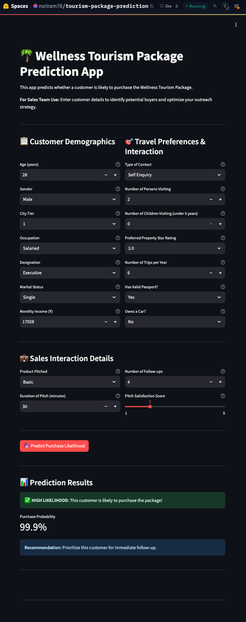

## Localhost MLFlow

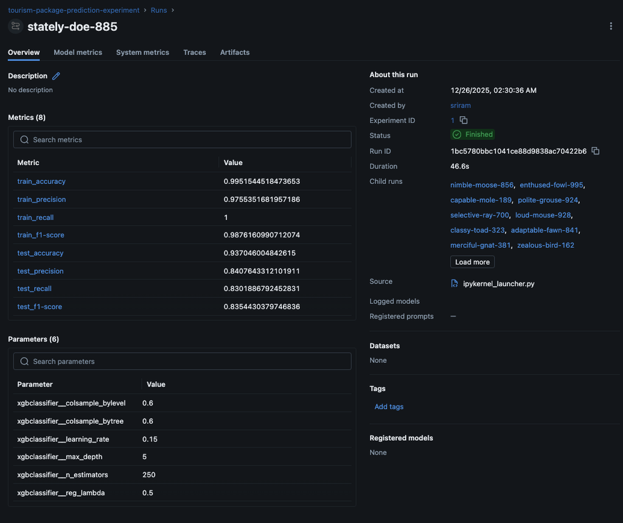

Power Ahead!